# Modelos Lineares

Autores: João Vitor da Silva Arend - 00577787, Davi Augusto F. da Silva

## Instruções

### Simulação Monte Carlo dos Betas do Modelo de Regressão

1. Faça uma simulação de tamanho n (25, 50, 100, 500, 1000) do modelo linear $Y= \beta_0 + \beta_1X + \epsilon$
2. Adicione um outlier nesse banco de dados
3. Estime os $\beta_0$, $\beta_1$ e $S^2$, calcule as estatísticas de teste e os seus respectivos p-valores
4. Guarde esses valores
5. Repita esse esperimento 1000 vezes, isto é, faça uma simulação de monte carlo
6. Faça um histograma e calcule a média, a variância e a mediana dos itens do passo 3
7. Qual a sua conclusão?
8. Entregue o codigo Rmarkdown e o html da tarefa

## Resolução

```r
set.seed(42)

n_values    <- c(25, 50, 100, 500, 1000)
rep         <- 1000
beta0       <- 3
beta1       <- 4
var_epsilon <- 4

retas <- function(n, beta1, beta0) {

  x       <- runif(n, -3, 3)
  epsilon <- rnorm(n, 0, sqrt(var_epsilon))
  y       <- beta0 + beta1 * x + epsilon

  y[n] <- y[n] + 42

  modelo       <- lm(y ~ x)
  beta0_chapeu <- modelo$coefficients[[1]]
  beta1_chapeu <- modelo$coefficients[[2]]
  residuos     <- sum(modelo$residuals^2) / (n - 1)

  summary_model <- summary(modelo)
  t_beta0       <- summary_model$coefficients[1, "t value"]
  p_beta0       <- summary_model$coefficients[1, "Pr(>|t|)"]
  t_beta1       <- summary_model$coefficients[2, "t value"]
  p_beta1       <- summary_model$coefficients[2, "Pr(>|t|)"]

  list(x            = x,
       y            = y,
       beta0_chapeu = beta0_chapeu,
       beta1_chapeu = beta1_chapeu,
       s2           = residuos,
       t_beta0      = t_beta0,
       p_beta0      = p_beta0,
       t_beta1      = t_beta1,
       p_beta1      = p_beta1
    )
}

results <- map(n_values, function(n) {

  amostras    <- map(1:rep, ~ retas(n, beta1, beta0))
  lista_beta0 <- map_dbl(amostras, "beta0_chapeu")
  lista_beta1 <- map_dbl(amostras, "beta1_chapeu")
  lista_s2    <- map_dbl(amostras, "s2")

  lista_t_beta0 <- map_dbl(amostras, "t_beta0")
  lista_p_beta0 <- map_dbl(amostras, "p_beta0")
  lista_t_beta1 <- map_dbl(amostras, "t_beta1")
  lista_p_beta1 <- map_dbl(amostras, "p_beta1")

  betas_estimados <- data.frame(
    beta0_chapeu_mc = lista_beta0,
    beta1_chapeu_mc = lista_beta1,
    s2_mc           = lista_s2,
    t_beta0_mc      = lista_t_beta0,
    p_beta0_mc      = lista_p_beta0,
    t_beta1_mc      = lista_t_beta1,
    p_beta1_mc      = lista_p_beta1
  )

  lista_x <- map(amostras, "x")
  matriz_x <- do.call(cbind, lista_x)

  lista_y <- map(amostras, "y")
  matriz_y <- do.call(cbind, lista_y)

  list(
    n = n,
    betas_estimados = betas_estimados,
    matriz_x = matriz_x,
    matriz_y = matriz_y
  )
})
```

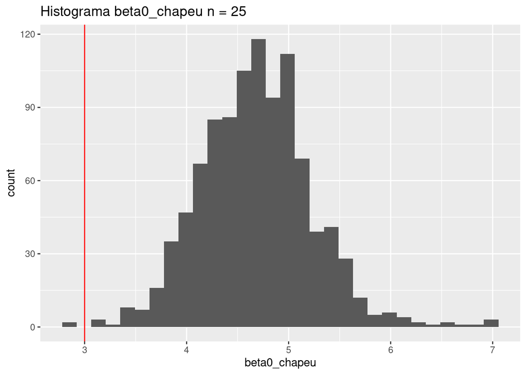

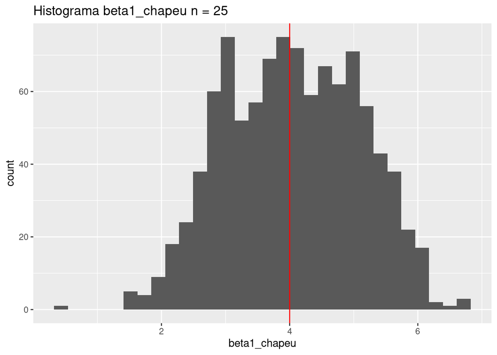

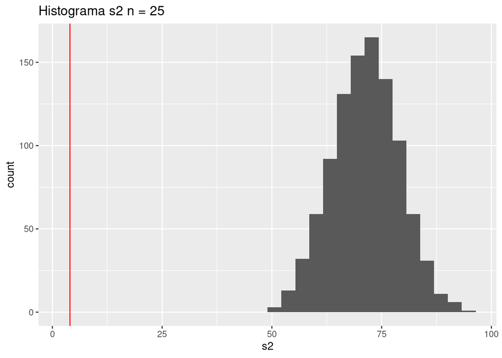

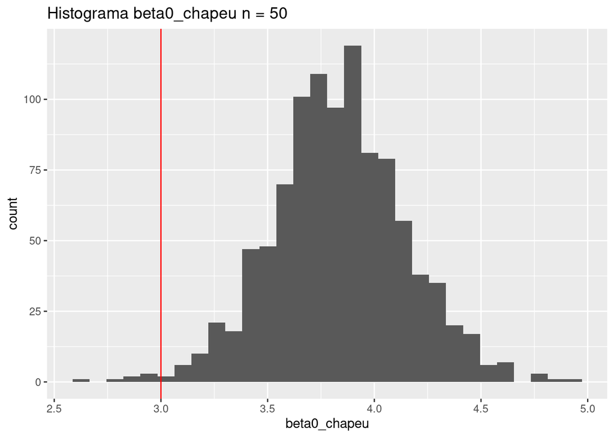

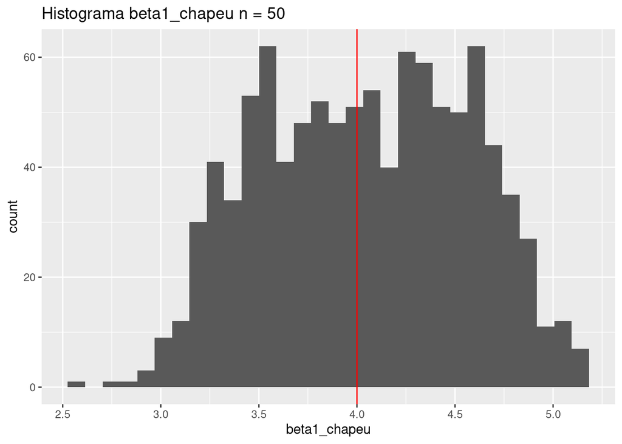

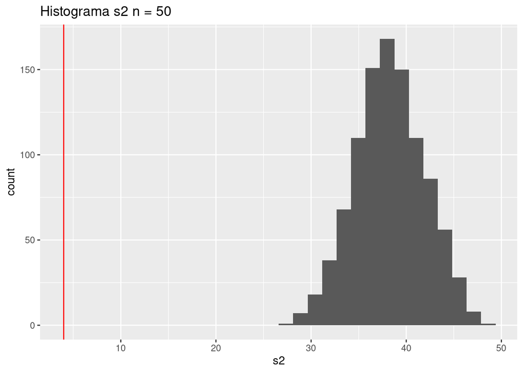

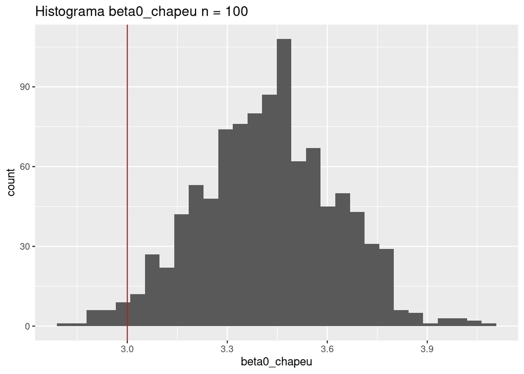

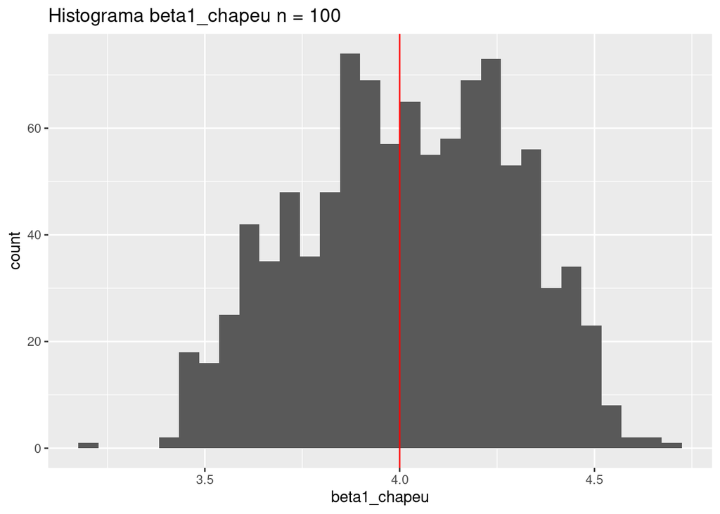

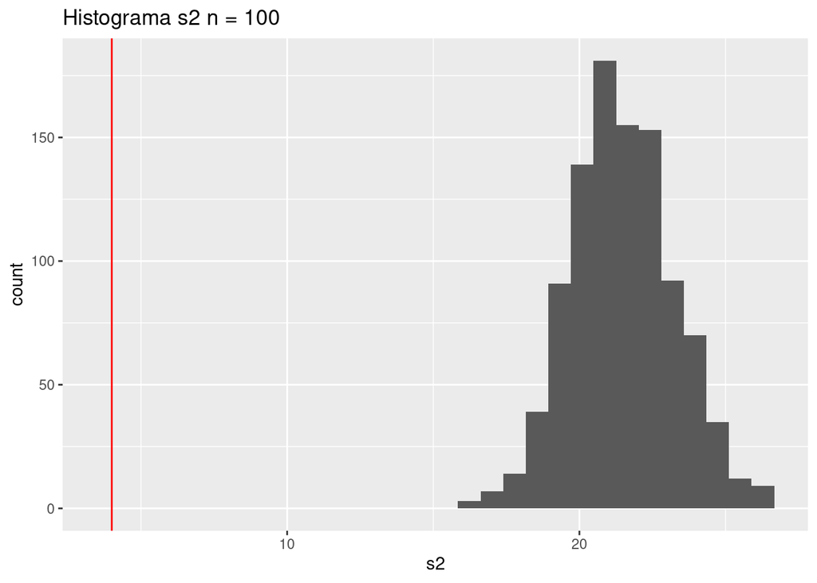

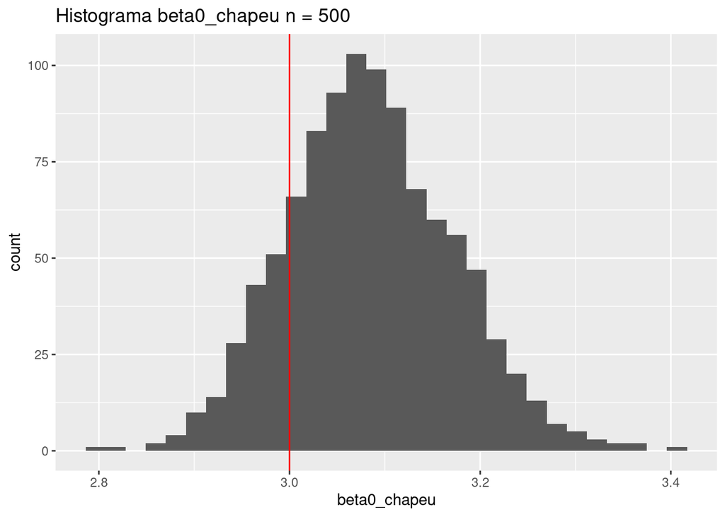

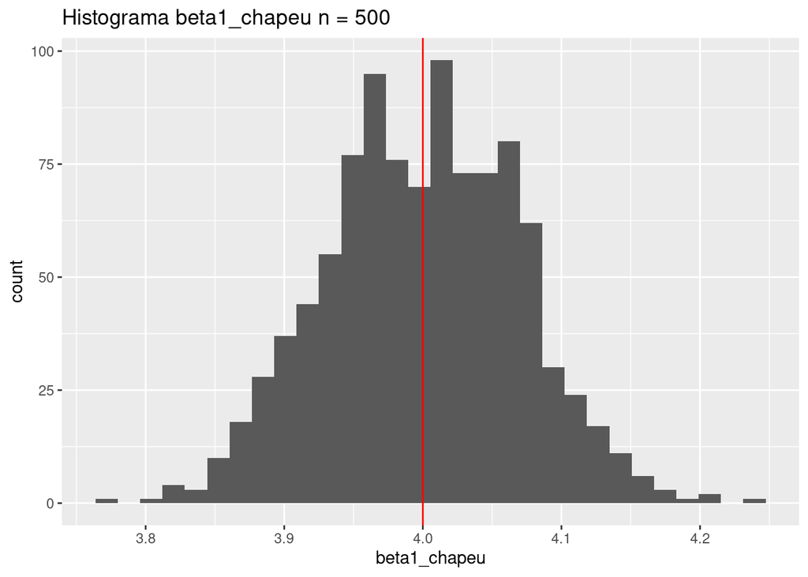

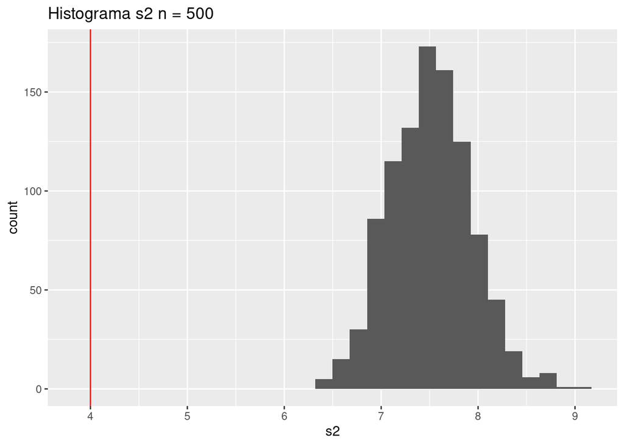

[3 more figures not shown]

```r
plot_histograms <- function(result) {
  n <- result$n
  betas_estimados <- result$betas_estimados

  p1 <- ggplot(betas_estimados, aes(x = beta0_chapeu_mc)) +
    geom_histogram() +
    geom_vline(xintercept = beta0, color = "red") +
    labs(title = paste("Histograma beta0_chapeu n =", n),
         x = "beta0_chapeu")

  p2 <- ggplot(betas_estimados, aes(x = beta1_chapeu_mc)) +
    geom_histogram() +
    geom_vline(xintercept = beta1, color = "red") +
    labs(title = paste("Histograma beta1_chapeu n =", n),
         x = "beta1_chapeu")

  p3 <- ggplot(betas_estimados, aes(x = s2_mc)) +
    geom_histogram() +
    geom_vline(xintercept = var_epsilon, color = "red") +
    labs(title = paste("Histograma s2 n =", n),
         x = "s2")

  print(p1)
  print(p2)
  print(p3)
}

walk(results, plot_histograms)
```

```r
compute_summary_stats <- function(betas_estimados) {
  betas_estimados %>%
    summarize(
      mean_beta0_chapeu = mean(beta0_chapeu_mc),
      var_beta0_chapeu = var(beta0_chapeu_mc),
      median_beta0_chapeu = median(beta0_chapeu_mc),

      mean_beta1_chapeu = mean(beta1_chapeu_mc),
      var_beta1_chapeu = var(beta1_chapeu_mc),
      median_beta1_chapeu = median(beta1_chapeu_mc),

      mean_s2 = mean(s2_mc),
      var_s2 = var(s2_mc),
      median_s2 = median(s2_mc),

      #mean_t_beta0 = mean(t_beta0_mc),
      #var_t_beta0 = var(t_beta0_mc),
      #median_t_beta0 = median(t_beta0_mc),

      #mean_p_beta0 = mean(p_beta0_mc),
      #var_p_beta0 = var(p_beta0_mc),
      #median_p_beta0 = median(p_beta0_mc),

      #mean_t_beta1 = mean(t_beta1_mc),
      #var_t_beta1 = var(t_beta1_mc),
      #median_t_beta1 = median(t_beta1_mc),

      #mean_p_beta1 = mean(p_beta1_mc),
      #var_p_beta1 = var(p_beta1_mc),
      #median_p_beta1 = median(p_beta1_mc)
    )
}

summary_stats <- map_df(results, function(result) {
  n <- result$n
  betas_estimados <- result$betas_estimados

  stats <- compute_summary_stats(betas_estimados)
  stats %>% mutate(n = n)
})

print(summary_stats)
```

```
##   mean_beta0_chapeu var_beta0_chapeu median_beta0_chapeu mean_beta1_chapeu
## 1          4.683561      0.302697847            4.684596          4.055767
## 2          3.834098      0.097358293            3.835100          4.042264
## 3          3.422476      0.042143905            3.426638          4.017688
## 4          3.084571      0.007601174            3.081083          3.999850
## 5          3.040594      0.004229794            3.040232          4.003029
##   var_beta1_chapeu median_beta1_chapeu   mean_s2      var_s2 median_s2    n
## 1      1.093327304            4.033458 71.297805 57.03041433 71.396394   25
## 2      0.273574014            4.054446 38.264459 13.22260561 38.106687   50
## 3      0.073016444            4.028705 21.469933  3.07576797 21.390543  100
## 4      0.004857691            4.001656  7.510589  0.17731674  7.508630  500
## 5      0.001752106            4.002422  5.761473  0.05687016  5.755107 1000
```

## Conclusão

Adicionando um outlier podemos obeservar que as distribuições dos betas e de $S^2$ ficam mais dispersas. Em especial a de $S^2$ que acaba ficando bem deslocada do real parâmetro. Entretando com o aumento do tamanho da amostra, as estimativas dos betas e do $S^2$ tendem a ficar mais estáveis e menos sensíveis ao outlier, indicando robustez do modelo conforme $n$ aumenta. Um outlier atrapalha a forma funcional linear e a homocasticidade e assim consequentemente a normalidade.